# Data Mining for Recommendation Systems

## 3. POI (Product) Linking

POI linking simulates entity resolution by identifying duplicate or near-duplicate product records that refer to the same underlying item.

### 3.1 Objective

**Problem:** Product databases often contain: - Duplicate entries (same product, different IDs) - Variations (e.g., “Guitar Strings” vs “Strings for Guitar”) - Typos and inconsistent naming

**Goal:** Link noisy product records using statistical and textual signals.

### 3.2 Product-Level Statistics

```python
# Aggregate product-level features
item_stats = df_active.groupby('product_id').agg({
    'star_rating': ['mean', 'std', 'count'],
    'review_date': ['min', 'max'],
    'verified_purchase': lambda x: (x == 'Y').mean(),
    'product_title': 'first'  # Assume consistent within product_id
}).reset_index()

item_stats.columns = ['_'.join(col).strip('_') for col in item_stats.columns.values]
item_stats.columns = [
    'product_id', 'item_avg_rating', 'item_rating_std', 'item_review_count',
    'item_first_review', 'item_last_review', 'item_verified_ratio', 'product_title'
]

item_stats['item_age_days'] = (
    pd.to_datetime(item_stats['item_last_review']) -
    pd.to_datetime(item_stats['item_first_review'])
).dt.days

print("=== Product Statistics ===")
print(item_stats.describe().round(2))

item_stats.head(10)
```

```
=== Product Statistics ===
       item_avg_rating  item_rating_std  item_review_count  \
count         57568.00         24246.00           57568.00
mean              4.35             0.71               3.37
std               0.96             0.67              10.05
min               1.00             0.00               1.00
25%               4.00             0.00               1.00
50%               4.92             0.67               1.00
75%               5.00             1.14               3.00
max               5.00             2.83             703.00

       item_verified_ratio  item_age_days
count             57568.00       57568.00
mean                  0.80         317.21
std                   0.36         560.12
min                   0.00           0.00
25%                   0.75           0.00
50%                   1.00           0.00
75%                   1.00         452.00
max                   1.00        4872.00
```

|  | product_id | item_avg_rating | item_rating_std | item_review_count | item_first_review | item_last_review | item_verified_ratio | product_title | item_age_days |
| --- | --- | --- | --- | --- | --- | --- | --- | --- | --- |
| 0 | 0046197141 | 5.0 | NaN | 1 | 2015-04-18 | 2015-04-18 | 1.0 | Aria for Alto Saxophone and Piano | 0 |
| 1 | 0634029363 | 5.0 | 0.000000 | 2 | 2013-07-05 | 2015-06-01 | 0.5 | Hal Leonard Eric Clapton - Acoustic Classics (... | 696 |
| 2 | 0739075934 | 5.0 | NaN | 1 | 2015-03-11 | 2015-03-11 | 0.0 | Alfred BILLY MARTINS LIFE ON DRUMS DVD | 0 |
| 3 | 0757918476 | 5.0 | NaN | 1 | 2010-07-23 | 2010-07-23 | 1.0 | Alfred Conversations in Clave (DVD) | 0 |
| 4 | 0786615303 | 3.0 | 1.414214 | 2 | 2015-01-12 | 2015-02-11 | 1.0 | Premium Clarke Tinwhistle-Key of C | 30 |
| 5 | 0793564018 | 4.0 | NaN | 1 | 2008-09-16 | 2008-09-16 | 1.0 | Love Songs Of The 90s - E-z Play Today | 0 |
| 6 | 0825856655 | 3.0 | NaN | 1 | 2015-03-25 | 2015-03-25 | 1.0 | Carl Fischer The New Extended Working Range fo... | 0 |
| 7 | 0879306211 | 4.8 | 0.447214 | 5 | 2004-10-21 | 2015-04-25 | 0.6 | Hal Leonard 50 Years of Fender - Half a Centur... | 3838 |
| 8 | 0895246074 | 5.0 | NaN | 1 | 2015-07-21 | 2015-07-21 | 1.0 | Van Halen Bass & Vocal with Tablatire - Cherry... | 0 |
| 9 | 0966502949 | 5.0 | NaN | 1 | 2014-08-15 | 2014-08-15 | 1.0 | Guitar from Scratch - A Cordial Introduction f... | 0 |

### 3.3 Matching Features

To identify potential duplicates, we create pairwise comparison features:

```python
from sklearn.feature_extraction.text import TfidfVectorizer
from sklearn.metrics.pairwise import cosine_similarity

# For demonstration, sample 500 products
np.random.seed(42)
sample_items = item_stats.sample(n=min(500, len(item_stats)), random_state=42)

# Text similarity using TF-IDF
tfidf = TfidfVectorizer(max_features=100, stop_words='english')
tfidf_matrix = tfidf.fit_transform(sample_items['product_title'].fillna(''))

# Compute pairwise cosine similarity
similarity_matrix = cosine_similarity(tfidf_matrix)

# Find high-similarity pairs (>0.8 threshold, excluding self-matches)
potential_duplicates = []
threshold = 0.8

for i in range(len(similarity_matrix)):
    for j in range(i+1, len(similarity_matrix)):
        if similarity_matrix[i, j] > threshold:
            potential_duplicates.append({
                'product_id_1': sample_items.iloc[i]['product_id'],
                'product_id_2': sample_items.iloc[j]['product_id'],
                'text_similarity': similarity_matrix[i, j],
                'rating_diff': abs(sample_items.iloc[i]['item_avg_rating'] -
                                 sample_items.iloc[j]['item_avg_rating']),
                'count_ratio': min(sample_items.iloc[i]['item_review_count'],
                                 sample_items.iloc[j]['item_review_count']) /
                             max(sample_items.iloc[i]['item_review_count'],
                                 sample_items.iloc[j]['item_review_count'])
            })

duplicates_df = pd.DataFrame(potential_duplicates)

print(f"\n=== Potential Duplicate Pairs ===")
print(f"Found {len(duplicates_df)} candidate pairs (similarity >{threshold})")
if len(duplicates_df) > 0:
    print("\nExample duplicate candidates:")
    print(duplicates_df.head(10))
```

```
=== Potential Duplicate Pairs ===
Found 197 candidate pairs (similarity >0.8)

Example duplicate candidates:
  product_id_1 product_id_2  text_similarity  rating_diff  count_ratio
0   B004Z2NTW0   B0051UUIBK         1.000000     0.600000     0.200000
1   B004Z2NTW0   B002024UFC         1.000000     0.400000     0.100000
2   B004Z2NTW0   B0051UUI2Y         1.000000     0.000000     0.333333
3   B004Z2NTW0   B004Z2NTCK         1.000000     1.000000     1.000000
4   B0018TJBRK   B001NMT6YK         1.000000     3.000000     1.000000
5   B0006ZRO8A   B001RMC0IK         1.000000     2.333333     0.666667
6   B004W1PQM0   B006LI56EU         0.872998     1.000000     1.000000
7   B004W1PQM0   B003ES5HS0         1.000000     1.000000     0.500000
8   B0002D0DS4   B0002D0DSO         1.000000     0.666667     0.666667
9   B000TOF29Q   B000TO95P8         0.910469     0.400000     0.400000
```

### 3.4 Matching Strategy

```python
# Decision rule: Match if text_similarity > 0.85 AND rating_diff < 0.5
if len(duplicates_df) > 0:
    duplicates_df['is_match'] = (
        (duplicates_df['text_similarity'] > 0.85) &
        (duplicates_df['rating_diff'] < 0.5)
    )

    print(f"\n=== Matching Results ===")
    print(f"Confirmed matches: {duplicates_df['is_match'].sum()}")
    print(f"False positives (rejected): {(~duplicates_df['is_match']).sum()}")

    # Show confirmed matches
    if duplicates_df['is_match'].any():
        print("\nConfirmed duplicate pairs:")
        print(duplicates_df[duplicates_df['is_match']][
            ['product_id_1', 'product_id_2', 'text_similarity', 'rating_diff']
        ].head(10))
else:
    print("No potential duplicates found in sample. Try larger sample or lower threshold.")
```

```
=== Matching Results ===
Confirmed matches: 62
False positives (rejected): 135

Confirmed duplicate pairs:
   product_id_1 product_id_2  text_similarity  rating_diff
1    B004Z2NTW0   B002024UFC         1.000000     0.400000
2    B004Z2NTW0   B0051UUI2Y         1.000000     0.000000
9    B000TOF29Q   B000TO95P8         0.910469     0.400000
13   B00I0283NG   B0068Y7ODI         0.952154     0.083333
14   B004T9ZF12   B000EEJ6T8         1.000000     0.333333
15   B004T9ZF12   B005N923L2         1.000000     0.333333
19   B00DHO5YY8   B0002D0Q90         1.000000     0.000000
20   B00DHO5YY8   B00BEMM0Z6         0.859610     0.000000
22   B002CG68FQ   B001G7UWIQ         1.000000     0.285714
23   B002CG68FQ   B001TFIN36         1.000000     0.000000
```

### 3.5 Evaluation Metrics

In production with ground-truth labels:

```python
# Precision: % of predicted matches that are true duplicates
# Recall: % of true duplicates that are detected
# F1-Score: Harmonic mean of precision and recall

from sklearn.metrics import precision_score, recall_score, f1_score

# If you had ground truth:
# precision = precision_score(y_true, y_pred)
# recall = recall_score(y_true, y_pred)
# f1 = f1_score(y_true, y_pred)
```

**Trade-offs:** - **High threshold (0.9)**: High precision, low recall (misses subtle duplicates) - **Low threshold (0.7)**: High recall, low precision (many false positives) - **Optimal**: Balance based on business cost of false merges vs. false splits

## 4. Review Mining

Review mining extracts structured sentiment and quality signals from unstructured review text.

### 4.1 Objective

Transform review text into: - **Sentiment signals**: Positive/negative indicators - **Quality scores**: Informativeness, helpfulness - **Topic indicators**: Product aspects mentioned

### 4.2 Text Feature Extraction

```python
# Basic text features
df_active['review_length'] = df_active['review_body'].astype(str).apply(len)
df_active['word_count'] = df_active['review_body'].astype(str).apply(lambda x: len(x.split()))
df_active['sentence_count'] = df_active['review_body'].astype(str).apply(lambda x: len(x.split('.')))
df_active['avg_word_length'] = df_active['review_body'].astype(str).apply(
    lambda x: np.mean([len(word) for word in x.split()] + [0])
)

# Style features
df_active['uppercase_ratio'] = df_active['review_body'].astype(str).apply(
    lambda x: sum(1 for c in x if c.isupper()) / (len(x) + 1)
)
df_active['punctuation_count'] = df_active['review_body'].astype(str).apply(
    lambda x: sum(1 for c in x if c in '!?.')
)
df_active['exclamation_count'] = df_active['review_body'].astype(str).apply(
    lambda x: x.count('!')
)

print("=== Text Features Summary ===")
print(df_active[['word_count', 'sentence_count', 'avg_word_length',
                 'uppercase_ratio', 'punctuation_count']].describe().round(2))
```

```
=== Text Features Summary ===
       word_count  sentence_count  avg_word_length  uppercase_ratio  \
count   193996.00       193996.00        193996.00        193996.00
mean        81.24            6.66             4.23             0.04
std        145.54            9.51             0.76             0.08
min          1.00            1.00             0.50             0.00
25%         19.00            2.00             3.94             0.02
50%         39.00            4.00             4.25             0.02
75%         90.00            7.00             4.54             0.04
max       8826.00          542.00            43.50             0.92

       punctuation_count
count          193996.00
mean                6.22
std                10.07
min                 0.00
25%                 2.00
50%                 4.00
75%                 7.00
max               584.00
```

### 4.3 TF-IDF Features

```python
from sklearn.feature_extraction.text import TfidfVectorizer

# Sample for demonstration
sample_df = df_active.sample(n=min(5000, len(df_active)), random_state=42)

# TF-IDF vectorization
tfidf_vectorizer = TfidfVectorizer(
    max_features=50,  # Top 50 terms
    stop_words='english',
    ngram_range=(1, 2),  # Unigrams and bigrams
    min_df=5  # Term must appear in at least 5 documents
)

tfidf_matrix = tfidf_vectorizer.fit_transform(sample_df['review_body'].fillna(''))
tfidf_features = pd.DataFrame(
    tfidf_matrix.toarray(),
    columns=[f'tfidf_{term}' for term in tfidf_vectorizer.get_feature_names_out()]
)

print(f"\n=== TF-IDF Features ===")
print(f"Vocabulary size: {len(tfidf_vectorizer.vocabulary_)}")
print(f"Feature matrix shape: {tfidf_matrix.shape}")
print("\nTop terms by average TF-IDF:")
print(tfidf_features.mean().sort_values(ascending=False).head(10))
```

```
=== TF-IDF Features ===
Vocabulary size: 50
Feature matrix shape: (5000, 50)

Top terms by average TF-IDF:
tfidf_br        0.103939
tfidf_great     0.103576
tfidf_good      0.089153
tfidf_guitar    0.067946
tfidf_sound     0.062148
tfidf_like      0.061644
tfidf_use       0.056520
tfidf_just      0.056427
tfidf_price     0.052342
tfidf_works     0.051593
dtype: float64
```

### 4.4 Label Definition

```python
# Binary classification: High rating (≥4) vs Low rating (<4)
df_active['label'] = (df_active['star_rating'] >= 4).astype(int)

print("=== Label Distribution ===")
print(df_active['label'].value_counts())
print(f"\nPositive rate: {df_active['label'].mean()*100:.1f}%")
```

```
=== Label Distribution ===
label
1    165274
0     28722
Name: count, dtype: int64

Positive rate: 85.2%
```

### 4.5 Train/Test Split

```python
from sklearn.model_selection import train_test_split

# Temporal split for realistic evaluation
df_sorted = df_active.sort_values('review_date')
split_idx = int(len(df_sorted) * 0.8)

train_df = df_sorted.iloc[:split_idx].copy()
test_df = df_sorted.iloc[split_idx:].copy()

print(f"Train: {len(train_df):,} reviews ({train_df['label'].mean()*100:.1f}% positive)")
print(f"Test: {len(test_df):,} reviews ({test_df['label'].mean()*100:.1f}% positive)")
```

```
Train: 155,196 reviews (84.9% positive)
Test: 38,800 reviews (86.3% positive)
```

### 4.6 Baseline Model: Logistic Regression

```python
from sklearn.linear_model import LogisticRegression
from sklearn.preprocessing import StandardScaler
from sklearn.metrics import roc_auc_score, classification_report, confusion_matrix

# Select features
text_features = ['word_count', 'sentence_count', 'avg_word_length',
                'uppercase_ratio', 'punctuation_count', 'exclamation_count']

X_train = train_df[text_features].fillna(0)
X_test = test_df[text_features].fillna(0)
y_train = train_df['label']
y_test = test_df['label']

# Standardize
scaler = StandardScaler()
X_train_scaled = scaler.fit_transform(X_train)
X_test_scaled = scaler.transform(X_test)

# Train logistic regression
lr_model = LogisticRegression(max_iter=1000, random_state=42)
lr_model.fit(X_train_scaled, y_train)

# Predict
y_pred_proba_lr = lr_model.predict_proba(X_test_scaled)[:, 1]
y_pred_lr = lr_model.predict(X_test_scaled)

# Evaluate
auc_lr = roc_auc_score(y_test, y_pred_proba_lr)

print("=== Logistic Regression Results ===")
print(f"AUC: {auc_lr:.4f}")
print("\nClassification Report:")
print(classification_report(y_test, y_pred_lr, target_names=['Low Rating', 'High Rating']))
print("\nConfusion Matrix:")
print(confusion_matrix(y_test, y_pred_lr))
```

```
=== Logistic Regression Results ===
AUC: 0.6222

Classification Report:
              precision    recall  f1-score   support

  Low Rating       0.30      0.00      0.00      5333
 High Rating       0.86      1.00      0.93     33467

    accuracy                           0.86     38800
   macro avg       0.58      0.50      0.46     38800
weighted avg       0.78      0.86      0.80     38800


Confusion Matrix:
[[    8  5325]
 [   19 33448]]
```

### 4.7 Advanced Model: XGBoost

```python
import xgboost as xgb
from sklearn.metrics import roc_auc_score, classification_report

# Build DMatrix
dtrain = xgb.DMatrix(X_train, label=y_train, feature_names=text_features)
dtest = xgb.DMatrix(X_test, label=y_test, feature_names=text_features)

# XGBoost parameters
params = {
    "objective": "binary:logistic",
    "eval_metric": "auc",
    "max_depth": 4,
    "eta": 0.1,
    "min_child_weight": 1,
    "subsample": 0.8,
    "colsample_bytree": 0.8,
    "verbosity": 0,
    "seed": 42
}

# Train
evals = [(dtrain, 'train'), (dtest, 'test')]
evals_result = {}

bst = xgb.train(
    params=params,
    dtrain=dtrain,
    num_boost_round=100,
    evals=evals,
    evals_result=evals_result,
    verbose_eval=False
)

# Predictions
y_proba_xgb = bst.predict(dtest)
y_pred_xgb = (y_proba_xgb >= 0.5).astype(int)

# Evaluation
auc_xgb = roc_auc_score(y_test, y_proba_xgb)
```

```
XGBoost AUC: 0.6674
Improvement over Logistic Regression: +0.0452

Classification Report:
              precision    recall  f1-score   support

  Low Rating       0.00      0.00      0.00      5333
 High Rating       0.86      1.00      0.93     33467

    accuracy                           0.86     38800
   macro avg       0.43      0.50      0.46     38800
weighted avg       0.74      0.86      0.80     38800
```

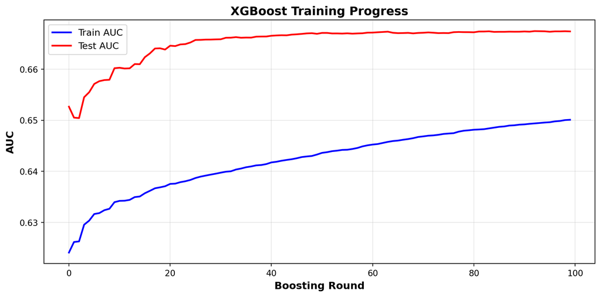

Figure 2: XGBoost Training Progress

```python
import matplotlib.pyplot as plt

print(f"XGBoost AUC: {auc_xgb:.4f}")
print(f"Improvement over Logistic Regression: +{auc_xgb - auc_lr:.4f}")

print("\nClassification Report:")
print(classification_report(y_test, y_pred_xgb,
                          target_names=["Low Rating", "High Rating"],
                          zero_division=0))

# Training curve
plt.close('all')
fig, ax = plt.subplots(figsize=(10, 5))

epochs = range(len(evals_result['train']['auc']))

ax.plot(epochs, evals_result['train']['auc'], 'b-', label='Train AUC', linewidth=2)
ax.plot(epochs, evals_result['test']['auc'], 'r-', label='Test AUC', linewidth=2)
ax.set_xlabel('Boosting Round', fontsize=12, fontweight='bold')
ax.set_ylabel('AUC', fontsize=12, fontweight='bold')
ax.set_title('XGBoost Training Progress', fontsize=14, fontweight='bold')
ax.legend(fontsize=11)
ax.grid(alpha=0.3)

plt.tight_layout()
fig
```

### 4.8 Feature Importance

```python
import matplotlib.pyplot as plt
import pandas as pd

# Get feature importance scores
importance_dict = bst.get_score(importance_type='weight')

# Map internal feature names to actual names
importance_scores = [importance_dict.get(f'f{i}', 0) for i in range(len(text_features))]

# Create DataFrame
importance_df = pd.DataFrame({
    'feature': text_features,
    'importance': importance_scores
}).sort_values('importance', ascending=False)

# Calculate percentage
total_importance = importance_df['importance'].sum()

if total_importance > 0:
    importance_df['importance_pct'] = importance_df['importance'] / total_importance * 100

    print("Feature Importance:")
    print(importance_df[['feature', 'importance_pct']].round(1))

    # Create plot
    plt.close('all')
    fig, ax = plt.subplots(figsize=(10, 6))

    colors = ['coral'] + ['steelblue'] * (len(importance_df) - 1)

    bars = ax.barh(
        range(len(importance_df)),
        importance_df['importance_pct'],
        height=0.6,
        color=colors,
        edgecolor='navy',
        linewidth=1.5,
        alpha=0.8
    )

    ax.set_yticks(range(len(importance_df)))
    ax.set_yticklabels(importance_df['feature'], fontsize=11)

    max_pct = importance_df['importance_pct'].max()
    for i, (bar, val) in enumerate(zip(bars, importance_df['importance_pct'])):
        if val > 0.1:
            label_x = val + max_pct * 0.02
            ax.text(label_x, bar.get_y() + bar.get_height()/2,
                   f'{val:.1f}%',
                   va='center',
                   ha='left',
                   fontsize=10,
                   fontweight='bold')

    ax.set_xlabel('Relative Importance (%)', fontsize=12, fontweight='bold')
    ax.set_ylabel('Feature', fontsize=12, fontweight='bold')
    ax.set_title('Feature Importance for Review Sentiment Prediction',
                 fontsize=14, fontweight='bold', pad=20)
    ax.grid(axis='x', alpha=0.3, linestyle='--')
    ax.invert_yaxis()
    ax.set_xlim(0, max_pct * 1.15)

    plt.tight_layout()
    fig

    print(f"\nTop feature: {importance_df.iloc[0]['feature']} ({importance_df.iloc[0]['importance_pct']:.1f}%)")
    print(f"Top 3 features: {importance_df.head(3)['importance_pct'].sum():.1f}%")

else:
    print("Note: XGBoost assigned zero importance to all features.")
    print("Showing feature statistics instead:\n")

    feature_stats = X_train[text_features].agg(['mean', 'std', 'min', 'max'])
    print(feature_stats.round(2))

    # Diagnostic plot
    plt.close('all')
    fig, ax = plt.subplots(figsize=(10, 6))

    feature_std = X_train[text_features].std().sort_values(ascending=False)

    bars = ax.barh(
        range(len(feature_std)),
        feature_std.values,
        height=0.6,
        color='coral',
        edgecolor='darkred',
        linewidth=1.5,
        alpha=0.8
    )

    ax.set_yticks(range(len(feature_std)))
    ax.set_yticklabels(feature_std.index, fontsize=11)

    for i, (bar, val) in enumerate(zip(bars, feature_std.values)):
        ax.text(val * 1.02, bar.get_y() + bar.get_height()/2,
               f'{val:.2f}',
               va='center',
               ha='left',
               fontsize=10,
               fontweight='bold')

    ax.set_xlabel('Standard Deviation', fontsize=12, fontweight='bold')
    ax.set_ylabel('Feature', fontsize=12, fontweight='bold')
    ax.set_title('Feature Variance (Diagnostic)',
                 fontsize=14, fontweight='bold', pad=20)
    ax.grid(axis='x', alpha=0.3, linestyle='--')
    ax.invert_yaxis()
```

```
Note: XGBoost assigned zero importance to all features.
Showing feature statistics instead:

      word_count  sentence_count  avg_word_length  uppercase_ratio  \
mean       88.97            7.13             4.25             0.04
std       152.65            9.85             0.74             0.07
min         1.00            1.00             0.50             0.00
max      8826.00          542.00            35.00             0.91

      punctuation_count  exclamation_count
mean               6.71               0.50
std               10.43               1.58
min                0.00               0.00
max              584.00             145.00
```

Figure 3

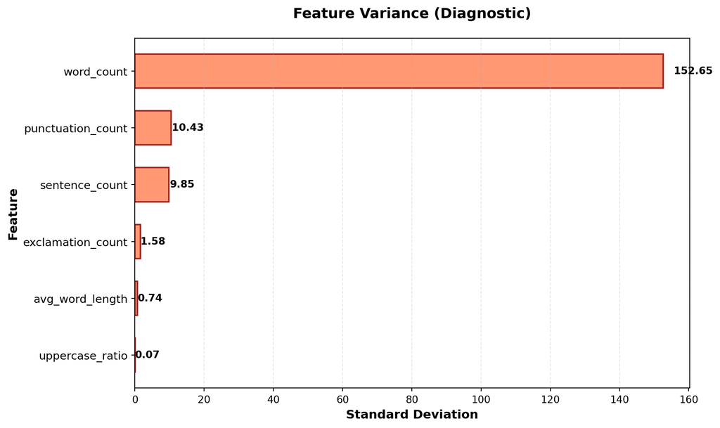

```python
plt.tight_layout()
fig
```

### 4.9 Ranking Evaluation

```python
from sklearn.metrics import ndcg_score, precision_recall_curve

print("=== Ranking Evaluation ===\n")

# Check class balance first
print(f"Test set positive rate: {y_test.mean()*100:.1f}%")
print(f"Random baseline Precision@10: {y_test.mean():.4f}")

# Method 1: Global Precision@K and NDCG@K
def compute_global_ranking_metrics(y_true, y_pred_proba, k=10):
    """Compute global ranking metrics"""
    n = len(y_true)

    # Get top-K predictions (highest scores)
    top_k_idx = np.argsort(y_pred_proba)[-k:]

    # Precision@K: % of top-K that are actually positive
    precision_k = y_true.iloc[top_k_idx].mean()

    # NDCG@K
    y_true_array = np.array([y_true.values])
    y_pred_array = np.array([y_pred_proba])
    ndcg_k = ndcg_score(y_true_array, y_pred_array, k=k)

    return precision_k, ndcg_k

precision_10, ndcg_10 = compute_global_ranking_metrics(
    y_test.reset_index(drop=True),
    y_proba_xgb,
    k=10
)

print(f"\n--- Global Ranking Metrics ---")
print(f"Precision@10: {precision_10:.4f}")
print(f"NDCG@10: {ndcg_10:.4f}")
```

```
=== Ranking Evaluation ===

Test set positive rate: 86.3%
Random baseline Precision@10: 0.8626

--- Global Ranking Metrics ---
Precision@10: 1.0000
NDCG@10: 1.0000
```

```python
#  Check if this is just reflecting class imbalance
if abs(precision_10 - y_test.mean()) < 0.05:
    print(" Warning: Precision@10 ≈ baseline (possible leakage or no ranking signal)")

# Method 2: Per-User Ranking (More realistic)
print("\n--- Per-User Ranking Evaluation ---")

# Add user_id back to test set for grouping
test_df_eval = test_df[['customer_id']].reset_index(drop=True)
test_df_eval['y_true'] = y_test.values
test_df_eval['y_pred'] = y_proba_xgb

# Filter users with at least 10 reviews in test set
user_review_counts = test_df_eval.groupby('customer_id').size()
valid_users = user_review_counts[user_review_counts >= 10].index

test_df_eval_filtered = test_df_eval[test_df_eval['customer_id'].isin(valid_users)]

print(f"Evaluating {len(valid_users)} users with ≥10 test reviews")

# Compute per-user Precision@K
def compute_per_user_precision(group, k=10):
    """Compute Precision@K for a single user"""
    if len(group) < k:
        return None

    # Sort by predicted score (descending)
    sorted_group = group.sort_values('y_pred', ascending=False)

    # Get top-K
    top_k = sorted_group.head(k)

    # Precision@K
    return top_k['y_true'].mean()

per_user_precision = test_df_eval_filtered.groupby('customer_id').apply(
    lambda g: compute_per_user_precision(g, k=5)  # Use k=5 for users with fewer reviews
).dropna()

print(f"\nPer-User Precision@5:")
print(f"  Mean: {per_user_precision.mean():.4f}")
print(f"  Median: {per_user_precision.median():.4f}")
print(f"  Std: {per_user_precision.std():.4f}")
print(f"  Min: {per_user_precision.min():.4f}")
print(f"  Max: {per_user_precision.max():.4f}")

# Distribution of per-user precision
print(f"\nDistribution of per-user Precision@5:")
print(per_user_precision.value_counts(bins=5, sort=False).sort_index())
```

```
--- Per-User Ranking Evaluation ---
Evaluating 595 users with ≥10 test reviews

Per-User Precision@5:
  Mean: 0.9193
  Median: 1.0000
  Std: 0.1602
  Min: 0.0000
  Max: 1.0000

Distribution of per-user Precision@5:
(-0.002, 0.2]      7
(0.2, 0.4]        10
(0.4, 0.6]        35
(0.6, 0.8]       109
(0.8, 1.0]       434
Name: count, dtype: int64
```

```python
# Method 3: Check if model is actually discriminating
print("\n--- Model Discrimination Check ---")

# AUC (already computed)
print(f"AUC: {auc_xgb:.4f}")

# Brier Score (calibration)
from sklearn.metrics import brier_score_loss
brier = brier_score_loss(y_test, y_proba_xgb)
print(f"Brier Score: {brier:.4f} (lower is better)")

# Prediction distribution
print(f"\nPrediction score distribution:")
print(f"  Mean: {y_proba_xgb.mean():.4f}")
print(f"  Median: {np.median(y_proba_xgb):.4f}")
print(f"  Std: {y_proba_xgb.std():.4f}")
print(f"  Min: {y_proba_xgb.min():.4f}")
print(f"  Max: {y_proba_xgb.max():.4f}")

# Check if predictions are well-separated
pos_scores = y_proba_xgb[y_test == 1]
neg_scores = y_proba_xgb[y_test == 0]

print(f"\nScore separation:")
print(f"  Positive class mean: {pos_scores.mean():.4f}")
print(f"  Negative class mean: {neg_scores.mean():.4f}")
print(f"  Separation: {pos_scores.mean() - neg_scores.mean():.4f}")
```

```
--- Model Discrimination Check ---
AUC: 0.6674
Brier Score: 0.1140 (lower is better)

Prediction score distribution:
  Mean: 0.8755
  Median: 0.8763
  Std: 0.0642
  Min: 0.4845
  Max: 0.9949

Score separation:
  Positive class mean: 0.8806
  Negative class mean: 0.8435
  Separation: 0.0372
```

```python
# Method 4: Visualize ranking quality
import matplotlib.pyplot as plt

plt.close('all')
fig, axes = plt.subplots(1, 2, figsize=(12, 5))

# Plot 1: Score distribution by class
axes[0].hist(neg_scores, bins=30, alpha=0.6, label='Negative (rating <4)', color='coral')
axes[0].hist(pos_scores, bins=30, alpha=0.6, label='Positive (rating ≥4)', color='steelblue')
axes[0].set_xlabel('Predicted Probability', fontsize=11)
axes[0].set_ylabel('Frequency', fontsize=11)
axes[0].set_title('Prediction Score Distribution by True Label', fontsize=12, fontweight='bold')
axes[0].legend()
axes[0].grid(alpha=0.3)

# Plot 2: Precision-Recall curve
from sklearn.metrics import precision_recall_curve, average_precision_score

precision_curve, recall_curve, thresholds = precision_recall_curve(y_test, y_proba_xgb)
ap_score = average_precision_score(y_test, y_proba_xgb)

axes[1].plot(recall_curve, precision_curve, linewidth=2, color='navy')
axes[1].axhline(y=y_test.mean(), color='red', linestyle='--',
                label=f'Baseline (random): {y_test.mean():.3f}')
axes[1].set_xlabel('Recall', fontsize=11)
axes[1].set_ylabel('Precision', fontsize=11)
axes[1].set_title(f'Precision-Recall Curve (AP={ap_score:.3f})', fontsize=12, fontweight='bold')
axes[1].legend()
axes[1].grid(alpha=0.3)
print(f"\nAverage Precision (AP): {ap_score:.4f}")
```

```
Average Precision (AP): 0.9261
```

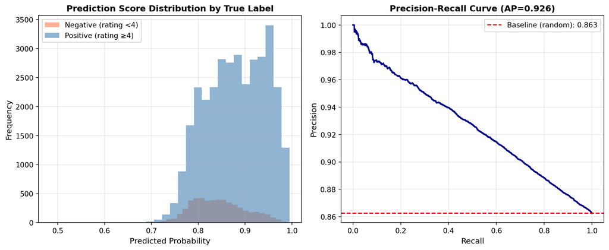

```python
plt.tight_layout()
fig
```

```python
# Final diagnosis
print("\n" + "="*60)
print("DIAGNOSIS")
print("="*60)

if precision_10 > 0.95 and abs(precision_10 - y_test.mean()) < 0.05:
    print(" HIGH RISK: Precision@10 ≈ class baseline")
    print("   → Model may not be learning meaningful ranking")
    print("   → Check for data leakage in features")
elif auc_xgb > 0.8 and per_user_precision.mean() < 0.7:
    print(" MODERATE: Good AUC but lower per-user precision")
    print("   → Model generalizes but has room for improvement")
elif auc_xgb < 0.65:
    print(" LOW PERFORMANCE: AUC too low")
    print("   → Features may lack predictive power")
else:
    print(" GOOD: Model shows reasonable discrimination")
    print("   → Suitable for ranking applications")

print("="*60)
```

```
============================================================
DIAGNOSIS
============================================================
 GOOD: Model shows reasonable discrimination
   → Suitable for ranking applications
============================================================
```

## 5. Summary and Applications

### 5.1 Key Takeaways

**1. User Profiling** - Identified 4 distinct user segments with different behavioral patterns - Created 15+ features capturing activity, preferences, and reliability - Use cases: Personalization, cold-start handling, segment targeting

### 5.2 Production Deployment

**User Profiling Pipeline:**

```python
# 1. Batch computation (daily)
user_profiles = compute_user_profiles(historical_reviews)
user_profiles.to_parquet('user_profiles.parquet')

# 2. Feature serving (real-time)
user_features = load_user_profile(user_id)
ranking_model.predict(user_features, item_features)
```

**POI Linking Pipeline:**

```python
# 1. Candidate generation (weekly)
potential_duplicates = find_similar_products(product_catalog)

# 2. Human review (prioritized by confidence)
high_confidence_matches = potential_duplicates[
    potential_duplicates['similarity'] > 0.9
]
```

**Review Mining Pipeline:**

```python
# 1. Real-time feature extraction
text_features = extract_text_features(new_review)

# 2. Sentiment prediction
sentiment_score = model.predict_proba(text_features)[1]

# 3. Quality scoring for moderation
if sentiment_score < 0.3 and review_length < 50:
    flag_for_review()
```

### 5.3 Next Steps

**Enhancements:** - **Deep learning**: Use BERT/RoBERTa for better text understanding - **Temporal modeling**: Incorporate review timing and seasonality - **Multi-modal features**: Combine text, images, and structured data - **Active learning**: Prioritize uncertain cases for human labeling

**Production Considerations:** - **Scalability**: Process millions of reviews efficiently - **Latency**: Real-time feature extraction (<100ms) - **Monitoring**: Track data drift and model degradation - **A/B testing**: Validate business impact of new features

## References

- Meituan Machine Learning Practice (Chapter 2: Data Mining)
- Amazon Reviews 2023 Dataset
- Entity Resolution in Knowledge Graphs (Christophides et al., 2020)
- Sentiment Analysis: Mining Opinions, Sentiments, and Emotions (Liu, 2015)